# ISYE 6402 Homework 4

# Background

For this data analysis, you will again analyze the currency exchange data but to a greater extent and including two different currencies for comparison. File *DailyCurrencyData.csv* contains the *daily* exchange rate of USD/JPY and USD/CNY from January 1999 through December 31st 2020. File *MonthlyCurrencyData.csv* contains the *monthly* exchange rate of USD/JPY and USD/CNY for the same time period. Similarly to homework 2, we will aggregate the daily data into weekly data. We will compare our analysis using ARMA modeling on both weekly and monthly data for the two currencies.

```r
library(zoo)
library(lubridate)
library(mgcv)
```

# Instructions on reading the data

To read the data in `R`, save the file in your working directory (make sure you have changed the directory if different from the R working directory) and read the data using the `R` function `read.csv()`

```r
daily <- read.csv("DailyCurrencyData.csv", head = TRUE)
monthly <- read.csv("MonthlyCurrencyData.csv", head = TRUE)

daily$Date <- as.Date(daily$Date, "%Y-%m-%d")
monthly$Date <- as.Date(paste0(monthly$Date, "-01"), "%Y-%m-%d")
colnames(monthly) <- colnames(daily)
```

# Question 1. Weekly vs Monthly Exploratory Data Analysis (20 points)

**1a.** Based on your intuition, when would you use weekly instead of monthly time series data?

*Response*

We can think of the difference between the monthly and the daily datasets to be a factor of math. The monthly set would be an average of the daily sets for that month. As such, we would expect to see much less volatility in the monthly set, and a less drastic jump from data points. However, this average, or smoothing, of data into a monthly set would inherently remove any intelligence gleaned from the analysis of outliers present in the daily dataset. I would expect as is the monthly data is smoothed, it inherently may exhibit more stationarity when compared to the daily dataset. Given the power of the current analytic tools, I expect equal trends of the data to emerge in a linear trend, however higher order model would lack the nuance when deployed on the monthly dataset. As for seasonality, there is a chance that there is seasonality within the month, and and this is “hidden” but the averaging. seasonality outside the period of a single month should emerge in both datasets.

**1b.** Plot the time series plots for both currency exchange rates comparing weekly vs monthly data. How do the weekly and monthly time series data compare? How do the time series for the two currencies compare?

```r
daily <- na.locf(daily)

weekly <- daily
weekly$Date <- floor_date(weekly$Date, "week")
weekly <- aggregate(weekly[, 2:3], by = list(weekly$Date), FUN = mean)
colnames(weekly)[1] <- "Date"
```

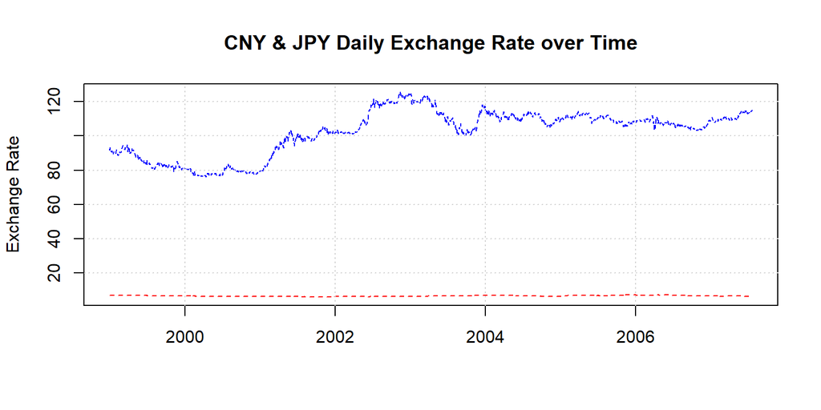

```r
#daily.CNY <- daily[, c("Date", "CNY")]
#daily.JPY <- daily[, c("Date", "JPY")]


monthly.CNY.ts <- ts(monthly$CNY, start = 1999, freq = 12)
monthly.JPY.ts <- ts(monthly$JPY, start = 1999, freq = 12)
daily.CNY.ts <- ts(daily$CNY, start = 1999, freq = 365.25)
daily.JPY.ts <- ts(daily$JPY, start = 1999, freq = 365.25)
weekly.CNY.ts <- ts(weekly$CNY, start = 1999, freq = 52)
weekly.JPY.ts <- ts(weekly$JPY, start = 1999, freq = 52)


#par(mfrow=c(1,2))
ts.plot(daily.JPY.ts,daily.CNY.ts, gpars=list(xlab="", ylab="Exchange Rate", lty=2, col=c("blue","red"),main = "CNY & JPY Daily Exchange Rate over Time"))
grid()
```

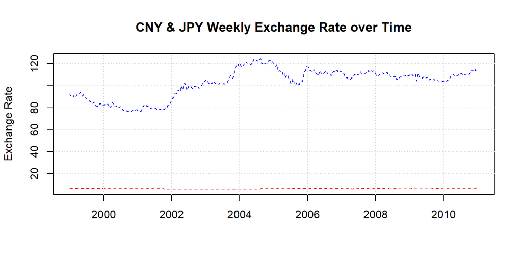

```r
ts.plot(weekly.JPY.ts,weekly.CNY.ts, gpars=list(xlab="", ylab="Exchange Rate", lty=2, col=c("blue","red"),main = "CNY & JPY Weekly Exchange Rate over Time"))
grid()
```

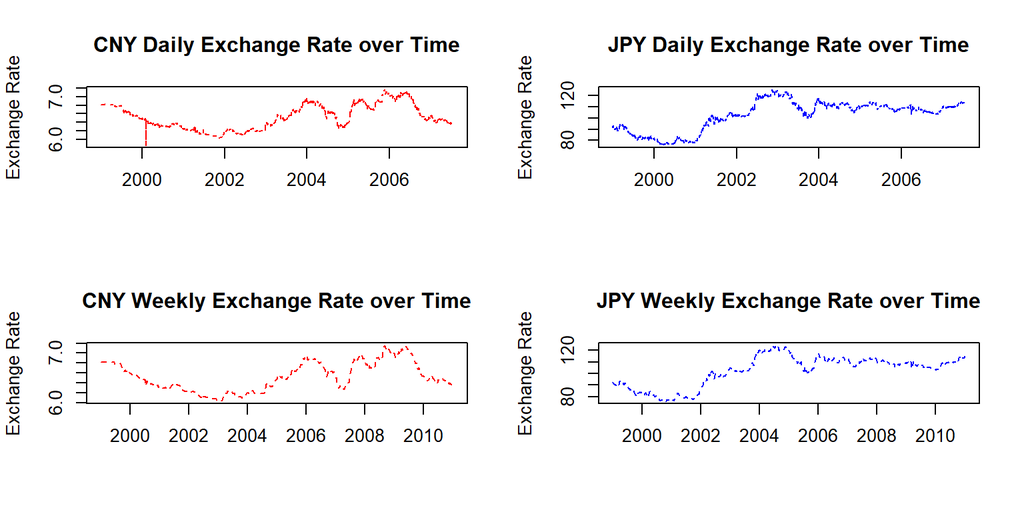

```r
par(mfrow=c(2,2))
ts.plot(daily.CNY.ts, gpars=list(xlab="", ylab="Exchange Rate", lty=2, col=c("red"),main = "CNY Daily Exchange Rate over Time"))
ts.plot(daily.JPY.ts, gpars=list(xlab="", ylab="Exchange Rate", lty=2, col=c("blue"),main = "JPY Daily Exchange Rate over Time"))

ts.plot(weekly.CNY.ts, gpars=list(xlab="", ylab="Exchange Rate", lty=2, col=c("red"),main = "CNY Weekly Exchange Rate over Time"))
ts.plot(weekly.JPY.ts, gpars=list(xlab="", ylab="Exchange Rate", lty=2, col=c("blue"),main = "JPY Weekly Exchange Rate over Time"))
```

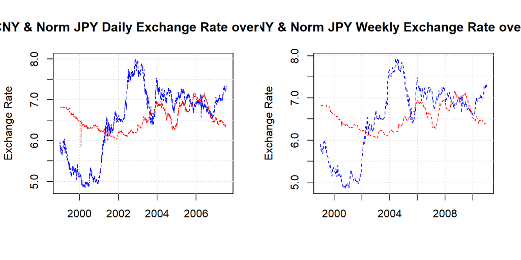

```r
ratio_daily =  (mean(daily.CNY.ts)/mean(daily.JPY.ts))
daily.JPY.ts.norm = daily.JPY.ts*ratio_daily

ratio_weekly =  (mean(weekly.CNY.ts)/mean(weekly.JPY.ts))
weekly.JPY.ts.norm = weekly.JPY.ts*ratio_weekly

par(mfrow=c(1,2))
ts.plot(daily.JPY.ts.norm,daily.CNY.ts, gpars=list(xlab="", ylab="Exchange Rate", lty=2, col=c("blue","red"),main = "CNY & Norm JPY Daily Exchange Rate over Time"))
grid()

ts.plot(weekly.JPY.ts.norm,weekly.CNY.ts, gpars=list(xlab="", ylab="Exchange Rate", lty=2, col=c("blue","red"),main = "CNY & Norm JPY Weekly Exchange Rate over Time"))
grid()
```

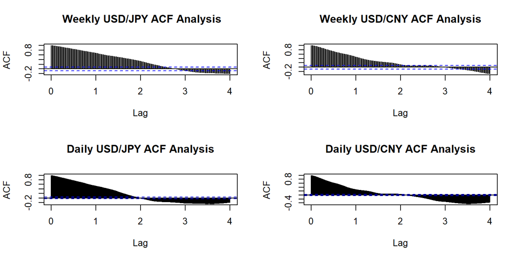

```r
par(mfrow=c(2,2))
acf(weekly.JPY.ts, lag.max = 52 * 4, xlab = "Lag", ylab = "ACF", main = " Weekly USD/JPY ACF Analysis")
acf(weekly.CNY.ts, lag.max = 52 * 4, xlab = "Lag", ylab = "ACF", main = "Weekly USD/CNY ACF Analysis")

acf(daily.JPY.ts, lag.max = 365.25 * 4, xlab = "Lag", ylab = "ACF", main = "Daily USD/JPY ACF Analysis")
acf(daily.CNY.ts, lag.max = 365.25 * 4, xlab = "Lag", ylab = "ACF", main = "Daily USD/CNY ACF Analysis")
```

*Response: Weekly vs Monthly Time Series data comparison*

In comparing the straight plots of the time series of each currancy, We see that issue of scale is apparent. because of the magnitude of the JPY conversion rate against the USD, when compared to the CNY, the CNY plots as a relatively straight line, as the different between the min and max values within the CNY dataset is significantly smaller than that of JPY.

In order to get around this issue of magnitude, we normalized the JPY data such that the real exchange rate was multiplied by the ratio of average CNY to average JPY. This allowed for the JPY to effectively be scaled into the CNY values’ range, and when plotted, shows the difference in the movement of the two currency exchange rates. We can see that even in this normalized plot, the range and variance of JPY is larger and more dynamic than compared with that of CNY.

Looking at the acf plots, we see that the CNY exihibits more stationarity when compared with JPY although a significant amount of the plot is outside the significance line, indicating that both are non-stationary. This makes sense, given that there are a vast number of political, economic and intangiable variables that impact the exchange rate. We are not suprised that the CNY shows less variance, given the strong coupling of these items between CNY and USD, in comparison with JPY and USD.

**1c.** Fit a non-parametric trend using splines regression to both the weekly and monthly time series data for both currencies. Overlay the fitted trends for each of the currency separately. How do the trends compare when comparing those fitted using the weekly and monthly data? How do the trends for the two currencies compare?

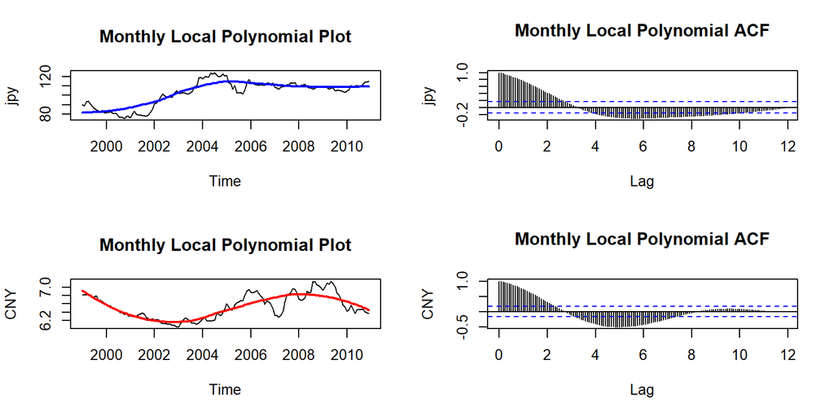

```r
TimeSeriesData = monthly.JPY.ts
## X-axis points converted to 0-1 scale, common in nonparametric regression
time.pts = c(1:length(TimeSeriesData))
time.pts = c(time.pts - min(time.pts))/max(time.pts)

## Fit a trend using non-parametric regression
## Local Polynomial Trend Estimation

loc.model = loess(TimeSeriesData~time.pts)
temp.fit.loc = ts(fitted(loc.model),start=1999,frequency=12)

par(mfrow=c(2,2))
ts.plot(TimeSeriesData,ylab="jpy",main="Monthly Local Polynomial Plot")
lines(temp.fit.loc,lwd=2,col="blue")

##Local Polynomial ACF
acf(temp.fit.loc,lag.max=2000, ylab="jpy",main="Monthly Local Polynomial ACF")

TimeSeriesData = monthly.CNY.ts
## X-axis points converted to 0-1 scale, common in nonparametric regression
time.pts = c(1:length(TimeSeriesData))
time.pts = c(time.pts - min(time.pts))/max(time.pts)

## Fit a trend using non-parametric regression
## Local Polynomial Trend Estimation

loc.model = loess(TimeSeriesData~time.pts)
temp.fit.loc = ts(fitted(loc.model),start=1999,frequency=12)

#par(mfrow=c(1,2))
ts.plot(TimeSeriesData,ylab="CNY",main="Monthly Local Polynomial Plot")
lines(temp.fit.loc,lwd=2,col="red")

##Local Polynomial ACF
acf(temp.fit.loc,lag.max=2000, ylab="CNY",main="Monthly Local Polynomial ACF")
```

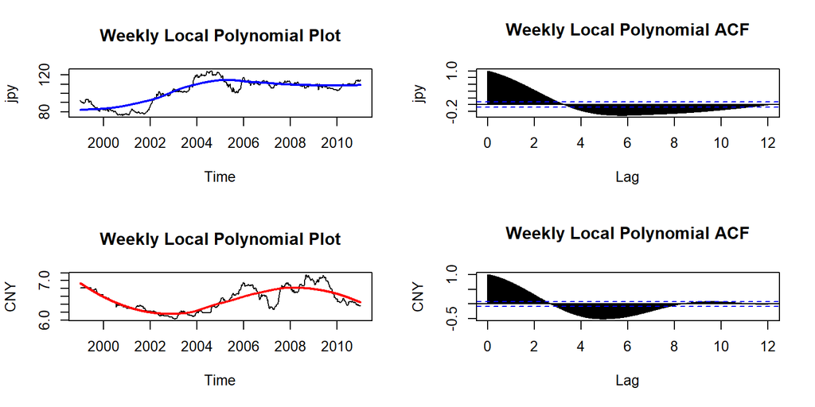

```r
TimeSeriesData = weekly.JPY.ts
## X-axis points converted to 0-1 scale, common in nonparametric regression
time.pts = c(1:length(TimeSeriesData))
time.pts = c(time.pts - min(time.pts))/max(time.pts)

## Fit a trend using non-parametric regression
## Local Polynomial Trend Estimation

loc.model = loess(TimeSeriesData~time.pts)
temp.fit.loc = ts(fitted(loc.model),start=1999,frequency=52)

par(mfrow=c(2,2))
ts.plot(TimeSeriesData,ylab="jpy",main="Weekly Local Polynomial Plot")
lines(temp.fit.loc,lwd=2,col="blue")

##Local Polynomial ACF
acf(temp.fit.loc,lag.max=2000, ylab="jpy",main="Weekly Local Polynomial ACF")

TimeSeriesData = weekly.CNY.ts
## X-axis points converted to 0-1 scale, common in nonparametric regression
time.pts = c(1:length(TimeSeriesData))
time.pts = c(time.pts - min(time.pts))/max(time.pts)

## Fit a trend using non-parametric regression
## Local Polynomial Trend Estimation

loc.model = loess(TimeSeriesData~time.pts)
temp.fit.loc = ts(fitted(loc.model),start=1999,frequency=52)

#par(mfrow=c(1,2))
ts.plot(TimeSeriesData,ylab="CNY",main="Weekly Local Polynomial Plot")
lines(temp.fit.loc,lwd=2,col="red")

##Local Polynomial ACF
acf(temp.fit.loc,lag.max=2000, ylab="CNY",main="Weekly Local Polynomial ACF")
```

*Response: Comparing Trend Estimation using weekly vs Monthly Data*

In looking at CNY, we can see that as the month is just the average of the week, the resulting model and acf is really an average as well. we see that the weekly plot of CNY model has more nuanced variance, better fitting the model, likely because of the nuance in the weekly measure, vs the monthly measure. We see that after the lag of 8, it is stationary. For the JPY plot, we see almost exactly the same results, with the lag = 10 the start of stationarity.

In looking at both currencies, we see that the model reasonably follows the data, with the weekly model being better as it captures the nuances of the inter-week variations within a month. The JPY has a large magnitude of max, min and mean, and thus the variance is greater. Both model show a stationarity after a period of lag, with CNY has a steeper trend towards stationarity.

**1d.** Take the 1st order difference of the time series weekly vs monthly data. Plot the ACF plots and compare. How do the difference time series for weekly and monthly data compare in terms of stationarity? How do the difference time series for the two currencies compare in terms of serial dependence and stationarity?

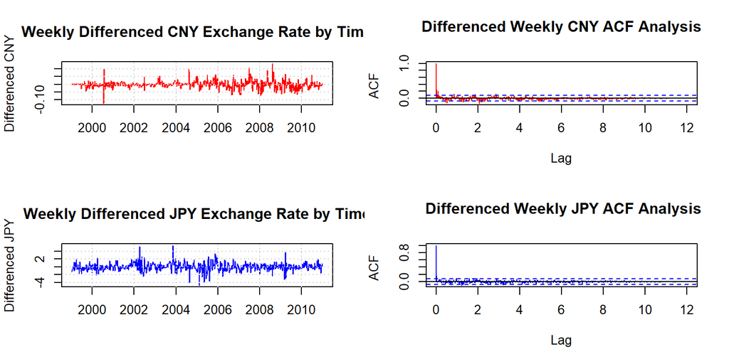

```r
par(mfrow=c(2,2))
#Weekly
ts.plot(diff(weekly.CNY.ts), col = "red", xlab = "", ylab = "Differenced CNY",
main = "Weekly Differenced CNY Exchange Rate by Time")
grid()
acf(diff(weekly.CNY.ts),col = "red",  lag.max = 52 * 40, xlab = "Lag", ylab = "ACF ", main = "Differenced Weekly CNY ACF Analysis")

ts.plot(diff(weekly.JPY.ts), col = "blue", xlab = "", ylab = "Differenced JPY",
main = "Weekly Differenced JPY Exchange Rate by Time")
grid()
acf(diff(weekly.JPY.ts), col = "blue", lag.max = 52 * 40, xlab = "Lag", ylab = "ACF ", main = " Differenced Weekly JPY ACF Analysis")
```

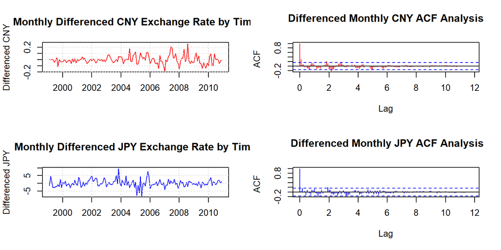

```r
#Monthly
ts.plot(diff(monthly.CNY.ts), col = "red", xlab = "", ylab = "Differenced CNY",
main = "Monthly Differenced CNY Exchange Rate by Time")
grid()
acf(diff(monthly.CNY.ts),col = "red",  lag.max = 12 * 40, xlab = "Lag", ylab = "ACF ", main = "Differenced Monthly CNY ACF Analysis")

ts.plot(diff(monthly.JPY.ts), col = "blue", xlab = "", ylab = "Differenced JPY",
main = "Monthly Differenced JPY Exchange Rate by Time")
grid()
acf(diff(monthly.JPY.ts), col = "blue", lag.max = 12 * 40, xlab = "Lag", ylab = "ACF ", main = " Differenced Monthly JPY ACF Analysis")
```

*Response: Exploratory Analysis of 1st Order Difference Data*

How do the difference time series for the two currencies compare in terms of serial dependence and stationarity

Comparing the monthly and weekly data for each, we see that the Monthly significance bands are wider than that of the weekly. This makes sense, since the monthly data points are farther away if the grouping of 4 weeks’ average is further from the previous, whereas for weeks, the there is less distance between consecutive points. These wider bands also then ensure that more of the ACF is within the significance bands, although both are generally stationary.

In comparing the currencies, we see that the JPY differencing results in a more stationary and smoother plot, in compared to that of CNY. Again, this is because of the wider absolute differences, when compared to CNY. We also see more serial dependence on JPY, with smaller “jumps” between data points.

# Question 2. ARIMA Fitting and Forecasting: Weekly Data Analysis (23 points)

**2a.** Divide the data into training and testing data set, where the training data exclude the last eight weeks of data (November and December 2021) with the testing data including the last eight weeks of data. For both currency exchange rates and using the training datasets, use the iterative model to fit an ARIMA(p,d,q) model with max AR and MA orders of 8, and a differencing order of 1 or 2. Display the summary of the final model fit. Compare statistical significance of the coefficients. Would a lower order model be suggested based on the statistical significance of the coefficients?

*Analyzing weekly data with ARIMA model fitting*

```r
#p value function
pvalue.coef <- function(tv) {  2 * (1 - pnorm(abs(tv)))}


weekly.CNY.ts.train = weekly.CNY.ts[0:618]
weekly.CNY.ts.test = weekly.CNY.ts[619:626]
weekly.JPY.ts.train = weekly.JPY.ts[0:618]
weekly.JPY.ts.test = weekly.JPY.ts[619:626]


###### Fit an AR(p) process for for p<= order.max ####
TimeSeriesData = weekly.CNY.ts.train
orderMax = 8

mod = ar(weekly.CNY.ts.train,order.max=orderMax)

# What is the selected order?

mod$order
```

```
## [1] 5
```

```r
# find the list of arguments provided by AR fit
summary(mod)
```

```
##              Length Class  Mode
## order          1    -none- numeric
## ar             5    -none- numeric
## var.pred       1    -none- numeric
## x.mean         1    -none- numeric
## aic            9    -none- numeric
## n.used         1    -none- numeric
## n.obs          1    -none- numeric
## order.max      1    -none- numeric
## partialacf     8    -none- numeric
## resid        618    -none- numeric
## method         1    -none- character
## series         1    -none- character
## frequency      1    -none- numeric
## call           3    -none- call
## asy.var.coef  25    -none- numeric
```

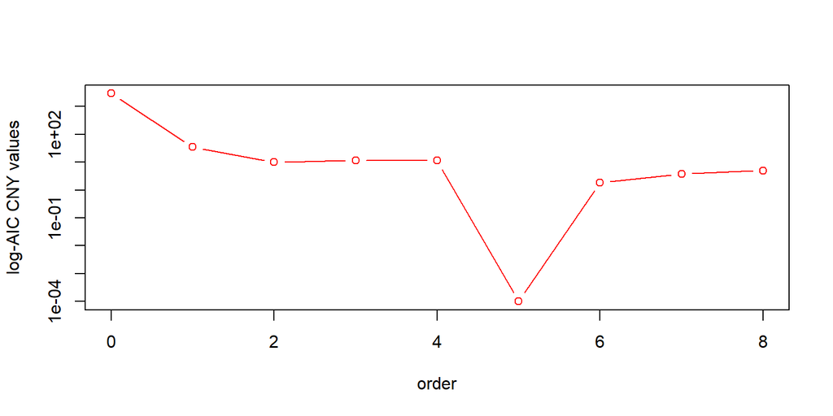

```r
# plot aic values
# On non-log scale it is difficult to detect the minimum.
plot(c(0:orderMax),mod$aic+.0001, type="b",log="y",xlab="order",ylab="log-AIC CNY values", col="red")
```

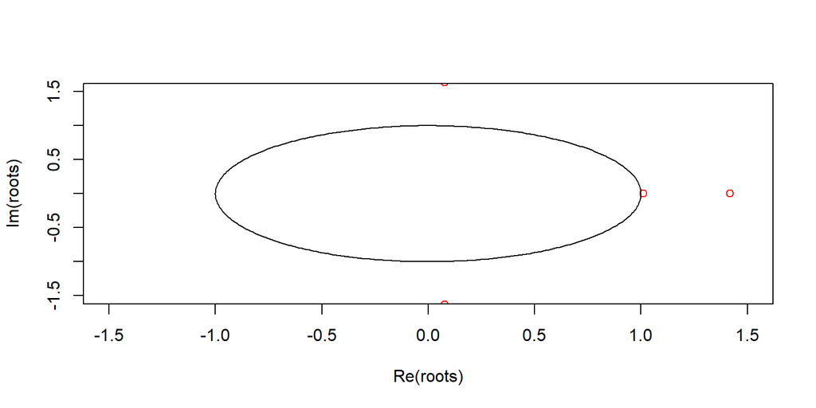

```r
# Are the roots of fitted AR within the unit circle?
# extract roots from the model output
roots = polyroot(c(1,(-mod$ar)))
# adjust the x and y -axis limits to include the full circle
plot(roots,xlim=c(-1.5,1.5),ylim=c(-1.5,1.5), col="red")
# draw a unit root circle
lines(complex(arg = seq(0,2*pi,len=300)))
```

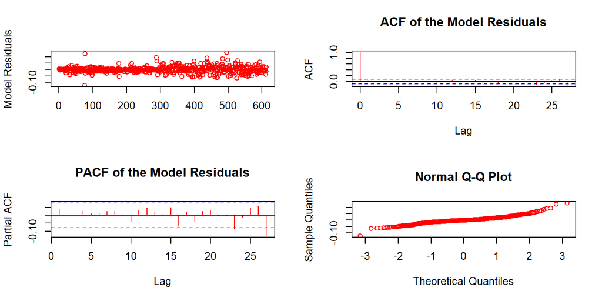

```r
# residuals analysis
resids = mod$resid[(mod$order+1): length(mod$resid)]

par(mfrow=c(2,2))
plot(resids,xlab="",ylab="Model Residuals", col="red")
acf(resids,main='ACF of the Model Residuals', col="red")
pacf(resids,main='PACF of the Model Residuals', col="red")
qqnorm(resids, col="red")
```

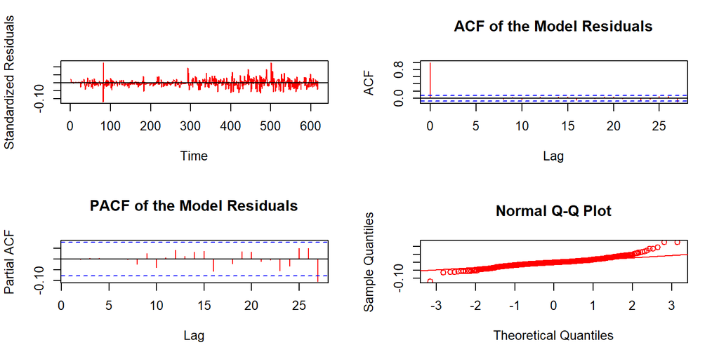

```r
###### Fit an ARMA(p,q) for some values of p and q #####
modarma = arima(TimeSeriesData, order = c(8,0,8),method = "ML")

par (mfrow=c(2,2))
plot(resid(modarma), ylab='Standardized Residuals', col="red")
abline(h=0)
acf(as.vector(resid(modarma)),main= 'ACF of the Model Residuals', col="red")
pacf(as.vector(resid(modarma)),main='PACF of the Model Residuals', col="red")
qqnorm(resid(modarma), col="red")
qqline(resid(modarma), col="red")
```

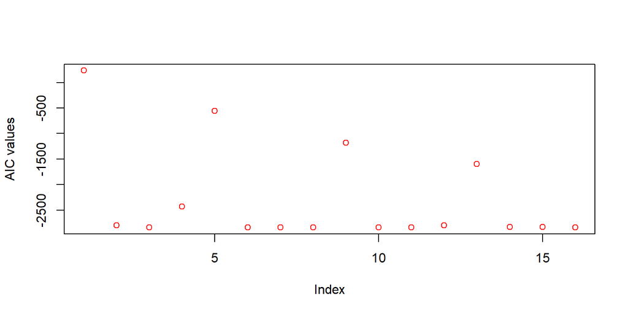

```r
## Order selection -- AIC
n = length(TimeSeriesData)
norder = 4
p = c(1:norder)-1; q = c(1:norder)-1; d = c(1:1)-1
aic = matrix(0,norder,norder,)
for(i in 1:norder){
   for(j in 1:norder){
    modij = arima(TimeSeriesData,order = c(p[i],0,q[j]), method='ML')
    aic[i,j] = modij$aic-2*(p[i]+q[j]+1)+2*(p[i]+q[j]+1)*n/(n-p[i]-q[j]-2)
   }
 }

par(mfrow=c(1,1))
#which order to select?
aicv = as.vector(aic)
plot(aicv,ylab="AIC values", col="red")
```

```r
indexp = rep(c(1:norder),norder)
indexq = rep(c(1:norder),each=norder)
indexaic = which(aicv == min(aicv))
porder = indexp[indexaic]-1
qorder = indexq[indexaic]-1


porder
```

```
## [1] 3
```

```r
qorder
```

```
## [1] 3
```

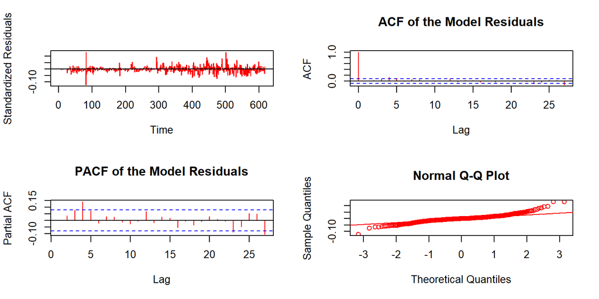

```r
#Create Final Model
final_model = arima(TimeSeriesData,order = c(porder,0,qorder), method='ML')

par (mfrow=c(2,2))
plot(resid(final_model), ylab='Standardized Residuals', col="red")
abline(h=0)
acf(as.vector(resid(final_model)),main= 'ACF of the Model Residuals', col="red")
pacf(as.vector(resid(final_model)),main='PACF of the Model Residuals', col="red")
qqnorm(resid(final_model), col="red")
qqline(resid(final_model), col="red")
```

```r
summary(final_model)
```

```
##           Length Class  Mode
## coef        7    -none- numeric
## sigma2      1    -none- numeric
## var.coef   49    -none- numeric
## mask        7    -none- logical
## loglik      1    -none- numeric
## aic         1    -none- numeric
## arma        7    -none- numeric
## residuals 618    ts     numeric
## call        4    -none- call
## series      1    -none- character
## code        1    -none- numeric
## n.cond      1    -none- numeric
## nobs        1    -none- numeric
## model      10    -none- list
```

```r
#### Test for Uncorrelated Residuals for the final model
Box.test(final_model$resid, lag = (porder+qorder+1), type = "Box-Pierce", fitdf = (porder+qorder))
```

```
##
##  Box-Pierce test
##
## data:  final_model$resid
## X-squared = 22.648, df = 1, p-value = 1.946e-06
```

```r
Box.test(final_model$resid, lag = (porder+qorder+1), type = "Ljung-Box", fitdf = (porder+qorder))
```

```
##
##  Box-Ljung test
##
## data:  final_model$resid
## X-squared = 22.876, df = 1, p-value = 1.728e-06
```

```r
#### Test Uncorrelated Residuals for the smaller model
Box.test(modarma$resid, lag = (porder+qorder+1), type = "Box-Pierce", fitdf = (porder+qorder))
```

```
##
##  Box-Pierce test
##
## data:  modarma$resid
## X-squared = 0.039027, df = 1, p-value = 0.8434
```

```r
Box.test(modarma$resid, lag = (porder+qorder+1), type = "Ljung-Box", fitdf = (porder+qorder))
```

```
##
##  Box-Ljung test
##
## data:  modarma$resid
## X-squared = 0.039427, df = 1, p-value = 0.8426
```

```r
#compute the test statistics
final_model_cn = final_model
tv.cny.weekly <-as.numeric(final_model_cn$coef)/as.numeric(sqrt(diag(final_model_cn$var.coef)))
pvalues.cny.weekly <- sapply(tv.cny.weekly, pvalue.coef)
tv.cny.weekly
```

```
## [1] -17.69048140  99.60397155  19.63714669  35.65897285  17.32308057
## [6]   7.15179952   0.02134349
```

```r
pvalues.cny.weekly
```

```
## [1] 0.000000e+00 0.000000e+00 0.000000e+00 0.000000e+00 0.000000e+00
## [6] 8.564260e-13 9.829717e-01
```

```r
#now repeat for JPY....
par(mfrow=c(1,1))
TimeSeriesData = weekly.JPY.ts.train
orderMax = 8

mod = ar(TimeSeriesData,order.max=orderMax)

# What is the selected order?
print(mod$order)
```

```
## [1] 2
```

```r
# find the list of arguments provided by AR fit
summary(mod)
```

```
##              Length Class  Mode
## order          1    -none- numeric
## ar             2    -none- numeric
## var.pred       1    -none- numeric
## x.mean         1    -none- numeric
## aic            9    -none- numeric
## n.used         1    -none- numeric
## n.obs          1    -none- numeric
## order.max      1    -none- numeric
## partialacf     8    -none- numeric
## resid        618    -none- numeric
## method         1    -none- character
## series         1    -none- character
## frequency      1    -none- numeric
## call           3    -none- call
## asy.var.coef   4    -none- numeric
```

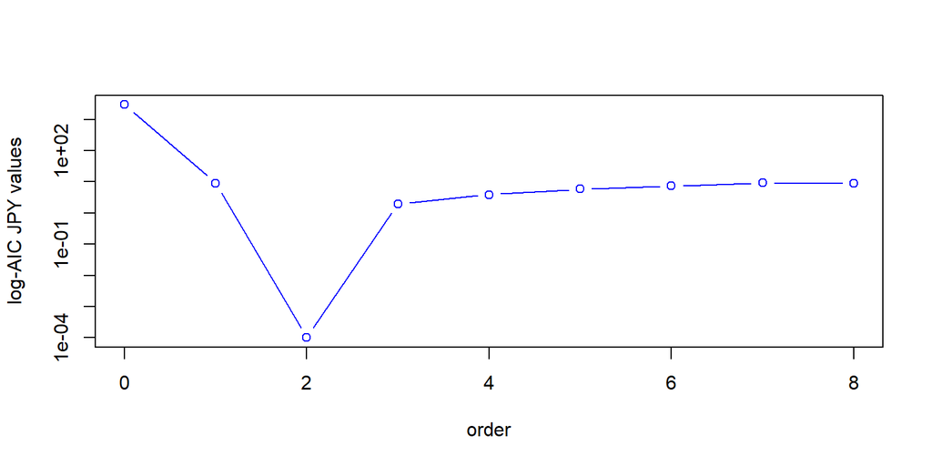

```r
# plot aic values
# On non-log scale it is difficult to detect the minimum.
plot(c(0:orderMax),mod$aic+.0001, type="b",log="y",xlab="order",ylab="log-AIC JPY values", col="blue")
```

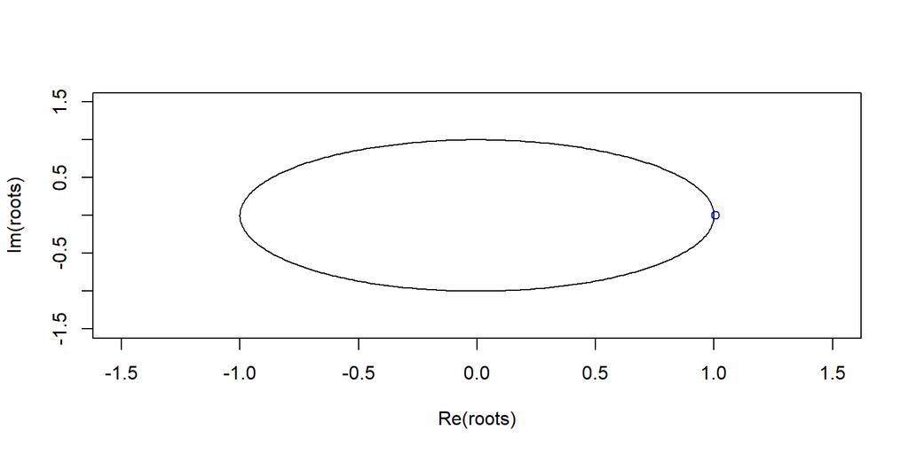

```r
# Are the roots of fitted AR within the unit circle?
# extract roots from the model output
roots = polyroot(c(1,(-mod$ar)))
# adjust the x and y -axis limits to include the full circle
plot(roots,xlim=c(-1.5,1.5),ylim=c(-1.5,1.5), col="blue")
# draw a unit root circle
lines(complex(arg = seq(0,2*pi,len=300)))
```

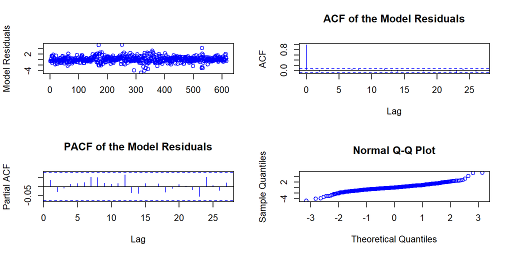

```r
# residuals analysis
resids = mod$resid[(mod$order+1): length(mod$resid)]

par(mfrow=c(2,2))
plot(resids,xlab="",ylab="Model Residuals", col="blue")
acf(resids,main='ACF of the Model Residuals', col="blue")
pacf(resids,main='PACF of the Model Residuals', col="blue")
qqnorm(resids, col="blue")
```

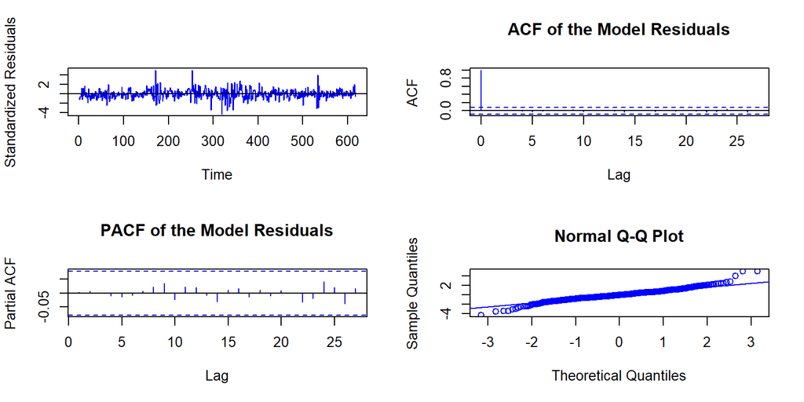

```r
###### Fit an ARMA(p,q) for some values of p and q #####
modarma = arima(TimeSeriesData, order = c(8,0,8),method = "ML")

par (mfrow=c(2,2))
plot(resid(modarma), ylab='Standardized Residuals', col="blue")
abline(h=0)
acf(as.vector(resid(modarma)),main= 'ACF of the Model Residuals', col="blue")
pacf(as.vector(resid(modarma)),main='PACF of the Model Residuals', col="blue")
qqnorm(resid(modarma), col="blue")
qqline(resid(modarma), col="blue")
```

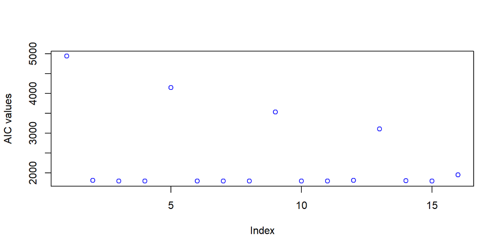

```r
## Order selection -- AIC
n = length(TimeSeriesData)
norder = 4
p = c(1:norder)-1; q = c(1:norder)-1
aic = matrix(0,norder,norder)
for(i in 1:norder){
   for(j in 1:norder){
    modij = arima(TimeSeriesData,order = c(p[i],0,q[j]), method='ML')
    aic[i,j] = modij$aic-2*(p[i]+q[j]+1)+2*(p[i]+q[j]+1)*n/(n-p[i]-q[j]-2)
   }
 }

par (mfrow=c(1,1))
#which order to select?
aicv = as.vector(aic)
plot(aicv,ylab="AIC values", col="blue")
```

```r
indexp = rep(c(1:norder),norder)
indexq = rep(c(1:norder),each=norder)
indexaic = which(aicv == min(aicv))
porder = indexp[indexaic]-1
qorder = indexq[indexaic]-1

porder
```

```
## [1] 1
```

```r
qorder
```

```
## [1] 1
```

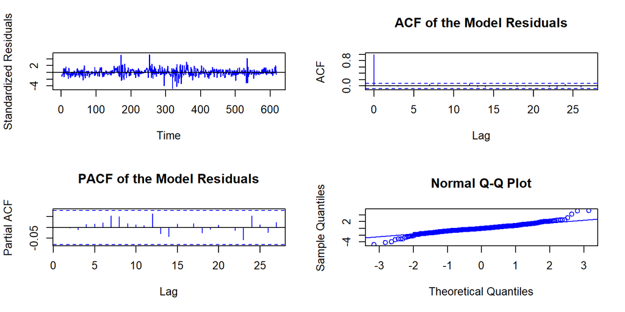

```r
#Create Final Model
final_model = arima(TimeSeriesData,order = c(porder,0,qorder), method='ML')

par (mfrow=c(2,2))
plot(resid(final_model), ylab='Standardized Residuals', col="blue")
abline(h=0)
acf(as.vector(resid(final_model)),main= 'ACF of the Model Residuals', col="blue")
pacf(as.vector(resid(final_model)),main='PACF of the Model Residuals', col="blue")
qqnorm(resid(final_model), col="blue")
qqline(resid(final_model), col="blue")
```

```r
summary(final_model)
```

```
##           Length Class  Mode
## coef        3    -none- numeric
## sigma2      1    -none- numeric
## var.coef    9    -none- numeric
## mask        3    -none- logical
## loglik      1    -none- numeric
## aic         1    -none- numeric
## arma        7    -none- numeric
## residuals 618    ts     numeric
## call        4    -none- call
## series      1    -none- character
## code        1    -none- numeric
## n.cond      1    -none- numeric
## nobs        1    -none- numeric
## model      10    -none- list
```

```r
#### Test for Uncorrelated Residuals for the final model
Box.test(final_model$resid, lag = (porder+qorder+1), type = "Box-Pierce", fitdf = (porder+qorder))
```

```
##
##  Box-Pierce test
##
## data:  final_model$resid
## X-squared = 0.080617, df = 1, p-value = 0.7765
```

```r
Box.test(final_model$resid, lag = (porder+qorder+1), type = "Ljung-Box", fitdf = (porder+qorder))
```

```
##
##  Box-Ljung test
##
## data:  final_model$resid
## X-squared = 0.08126, df = 1, p-value = 0.7756
```

```r
#### Test Uncorrelated Residuals for the smaller model
Box.test(modarma$resid, lag = (porder+qorder+1), type = "Box-Pierce", fitdf = (porder+qorder))
```

```
##
##  Box-Pierce test
##
## data:  modarma$resid
## X-squared = 0.029596, df = 1, p-value = 0.8634
```

```r
Box.test(modarma$resid, lag = (porder+qorder+1), type = "Ljung-Box", fitdf = (porder+qorder))
```

```
##
##  Box-Ljung test
##
## data:  modarma$resid
## X-squared = 0.029779, df = 1, p-value = 0.863
```

```r
#compute the test statistics
final_model_jpy = final_model
tv.jpy.weekly <-as.numeric(final_model_jpy$coef)/as.numeric(sqrt(diag(final_model_jpy$var.coef)))
pvalues.jpy.weekly <- sapply(tv.jpy.weekly, pvalue.coef)
tv.jpy.weekly
```

```
## [1] 311.746091   4.316459  12.659265
```

```r
pvalues.jpy.weekly
```

```
## [1] 0.000000e+00 1.585522e-05 0.000000e+00
```

*Response: Analysis of the ARIMA Fit for the Weekly Data*

In the CNY weekly final model, the optimal pdq is AR(3,0,3).  
In the JPY weekly final model, the optimal pdq is AR(1,0,1).

**2b.** Evaluate the model residuals using the ACF and PACF plots, the residual plot and residuals’ histogram as well as hypothesis testing for serial correlation for the selected models in (2a) for the two currencies. Does the model fit the time series data? Compare the model fit for the two currency exchange rates.

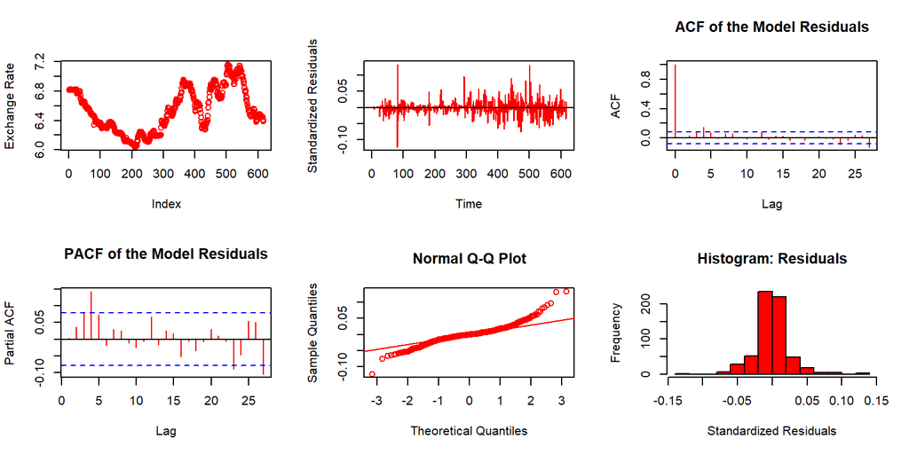

```r
modarma = final_model_cn
par (mfrow=c(2,3))
plot(weekly.CNY.ts.train, ylab='Exchange Rate', col="red")
plot(resid(modarma), ylab='Standardized Residuals', col="red")
abline(h=0)
acf(as.vector(resid(modarma)),main= 'ACF of the Model Residuals', col="red")
pacf(as.vector(resid(modarma)),main='PACF of the Model Residuals', col="red")
qqnorm(resid(modarma), col="red")
qqline(resid(modarma), col="red")
hist(resid(modarma),xlab='Standardized Residuals',main='Histogram: Residuals', col="red")
```

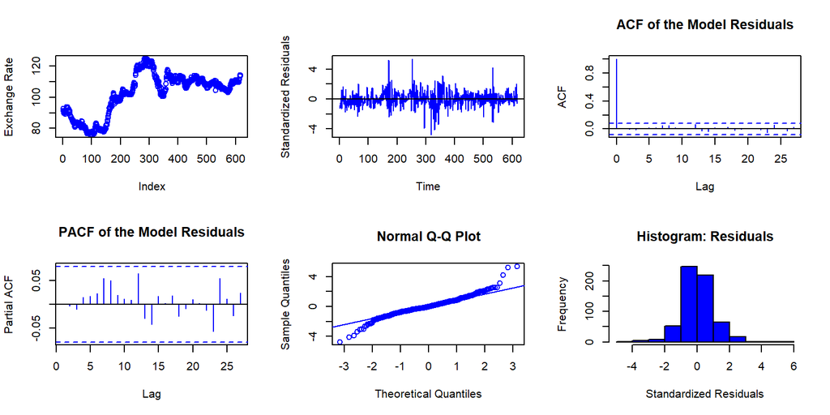

```r
modarma = final_model_jpy
par (mfrow=c(2,3))
plot(weekly.JPY.ts.train, ylab='Exchange Rate', col="blue")
plot(resid(modarma), ylab='Standardized Residuals', col="blue")
abline(h=0)
acf(as.vector(resid(modarma)),main= 'ACF of the Model Residuals', col="blue")
pacf(as.vector(resid(modarma)),main='PACF of the Model Residuals', col="blue")
qqnorm(resid(modarma), col="blue")
qqline(resid(modarma), col="blue")
hist(resid(modarma),xlab='Standardized Residuals',main='Histogram: Residuals', col="blue")
```

**2c.** For each currency exchange, apply the model identified in (2a) and forecast the last eight weeks of data. Plot the predicted data to compare the predicted values to the actual observed ones. Include 90% confidence intervals for the forecasts in the corresponding plots.

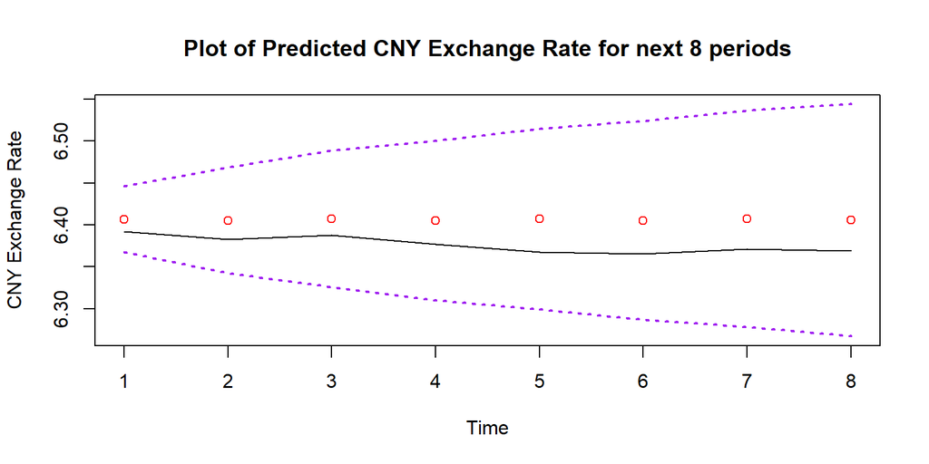

```r
#z=1.645

working.model = final_model_cn
TimeSeriesDataTest = weekly.CNY.ts.test
## Forecasting with ARIMA: 8 Weeks Ahead
n = length(TimeSeriesDataTest)
#nfit = n-14
#outvol = arima(volume.ts[1:nfit], order = c(5,1,5),seasonal = list(order = c(1,0,1),period=7),method = "ML")
out_pred = as.vector(predict(working.model,n.ahead=8))

## Compare predictions vs observed values with confidence bands
timevol=time(TimeSeriesDataTest)
ubound = out_pred$pred+1.645*out_pred$se
lbound = out_pred$pred-1.645*out_pred$se
ymin = min(lbound)
ymax = max(ubound)
par(mfrow=c(1,1))
plot(timevol,TimeSeriesDataTest,type="l", ylim=c(ymin,ymax), xlab="Time", ylab="CNY Exchange Rate", main = "Plot of Predicted CNY Exchange Rate for next 8 periods")
points(timevol[(1):n],out_pred$pred,col="red")
lines(timevol[(1):n],ubound,lty=3,lwd= 2, col="purple")
lines(timevol[(1):n],lbound,lty=3,lwd= 2, col="purple")
```

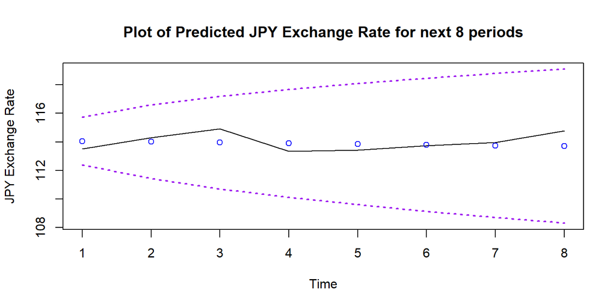

```r
out_pred_cny = out_pred
ubound_cny = ubound
lbound_cny = lbound

#Now for JPY
working.model = final_model_jpy
TimeSeriesDataTest = weekly.JPY.ts.test
## Forecasting with ARIMA: 8 Weeks Ahead
n = length(TimeSeriesDataTest)
out_pred = as.vector(predict(working.model,n.ahead=8))


## Compare predictions vs observed values with confidence bands
timevol=time(TimeSeriesDataTest)
ubound = out_pred$pred+1.645*out_pred$se
lbound = out_pred$pred-1.645*out_pred$se
ymin = min(lbound)
ymax = max(ubound)
par(mfrow=c(1,1))
plot(timevol,TimeSeriesDataTest,type="l", ylim=c(ymin,ymax), xlab="Time", ylab="JPY Exchange Rate", main = "Plot of Predicted JPY Exchange Rate for next 8 periods")
points(timevol[(1):n],out_pred$pred,col="blue")
lines(timevol[(1):n],ubound,lty=3,lwd= 2, col="purple")
lines(timevol[(1):n],lbound,lty=3,lwd= 2, col="purple")
```

```r
out_pred_jpy = out_pred
ubound_jpy = ubound
lbound_jpy = lbound
```

**2d.** Calculate Mean Absolute Percentage Error (MAPE) and Precision Measure (PM). How many observations are within the prediction bands? Compare the accuracy of the predictions for the two time series using these two measures.

```r
#library(MLmetrics)
#MAPE(out_pred$pred, weekly.CNY.ts.test) #as decimal

out_pred = out_pred_cny
TimeSeriesDataTest = weekly.CNY.ts.test
#MAPE
mean(abs((TimeSeriesDataTest-out_pred$pred)/TimeSeriesDataTest)) * 100 #in percent
```

```
## [1] 0.4651366
```

```r
### Precision Measure (PM)
sum((TimeSeriesDataTest - out_pred$pred)^2)/sum((TimeSeriesDataTest-mean(TimeSeriesDataTest))^2)
```

```
## [1] 10.97797
```

```r
out_pred = out_pred_jpy
TimeSeriesDataTest = weekly.JPY.ts.test
#MAPE
mean(abs((TimeSeriesDataTest-out_pred$pred)/TimeSeriesDataTest)) * 100 #in percent
```

```
## [1] 0.4512785
```

```r
### Precision Measure (PM)
sum((TimeSeriesDataTest - out_pred$pred)^2)/sum((TimeSeriesDataTest-mean(TimeSeriesDataTest))^2)
```

```
## [1] 1.158028
```

*Response: Prediction Accuracy*

For weekly CNY, the MAPE is 0.4651366 and the PM is 10.97797. We see from the plots above that all weekly data points, along with all the data, is within the 90% prediction bands.

For weekly JPY, the MAPE is 0.4512785 and the PM is 1.158028. We see from the plots above that all weekly data points, along with all the data, is within the 90% prediction bands.

In comparing the MAPE and PM for both currencies for the weekly data, we see that the MAPE is minimally higher for CNY with respect to JPY, however the PM is lower for JPY. MAPE estimates by minimizing absolute prediction errors, and since the JPY weekly value is lower than the CNY value, it suggests that the JPY is a better fit - although they are almost the same and likely no conclusions can be drawn from MAPE comparison. The closer the PM values is to zero, the better the prediction is. With a lower PM, the JPY weekly model is a better fit than that of CNY.

# Question 3. ARIMA Fitting: Monthly Data Analysis (17 points)

**3a.** Divide the data into training and testing data set, where the training data exclude the last two months of data (November and December 2021) with the testing data including the last two months. For both currency exchange rates and using the training datasets, use the iterative model to fit an ARIMA(p,d,q) model with max AR and MA orders of 8, and a differencing order of 1 or 2. Display the summary of the final model fit. Compare statistical significance of the coefficients. Compare the order selection from using monthly versus weekly data for each of the two currencies.

```r
monthly.CNY.ts.train = monthly.CNY.ts[0:142]
monthly.CNY.ts.test = monthly.CNY.ts[143:144]
monthly.JPY.ts.train = monthly.JPY.ts[0:142]
monthly.JPY.ts.test = monthly.JPY.ts[143:144]


###### Fit an AR(p) process for for p<= order.max ####
TimeSeriesData = monthly.CNY.ts.train
orderMax = 8

mod = ar(monthly.CNY.ts.train,order.max=orderMax)

# What is the selected order?
print(mod$order)
```

```
## [1] 2
```

```r
# find the list of arguments provided by AR fit
summary(mod)
```

```
##              Length Class  Mode
## order          1    -none- numeric
## ar             2    -none- numeric
## var.pred       1    -none- numeric
## x.mean         1    -none- numeric
## aic            9    -none- numeric
## n.used         1    -none- numeric
## n.obs          1    -none- numeric
## order.max      1    -none- numeric
## partialacf     8    -none- numeric
## resid        142    -none- numeric
## method         1    -none- character
## series         1    -none- character
## frequency      1    -none- numeric
## call           3    -none- call
## asy.var.coef   4    -none- numeric
```

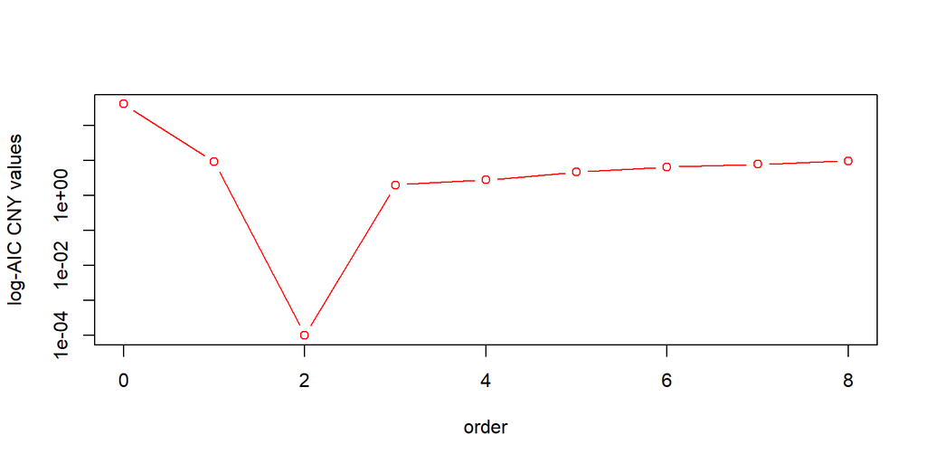

```r
# plot aic values
# On non-log scale it is difficult to detect the minimum.
plot(c(0:orderMax),mod$aic+.0001, type="b",log="y",xlab="order",ylab="log-AIC CNY values", col="red")
```

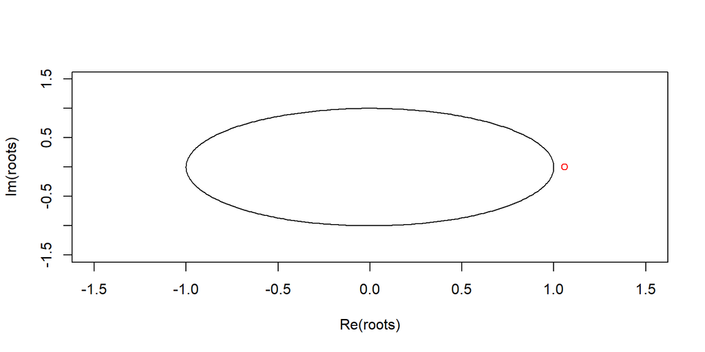

```r
# Are the roots of fitted AR within the unit circle?
# extract roots from the model output
roots = polyroot(c(1,(-mod$ar)))
# adjust the x and y -axis limits to include the full circle
plot(roots,xlim=c(-1.5,1.5),ylim=c(-1.5,1.5), col="red")
# draw a unit root circle
lines(complex(arg = seq(0,2*pi,len=300)))
```

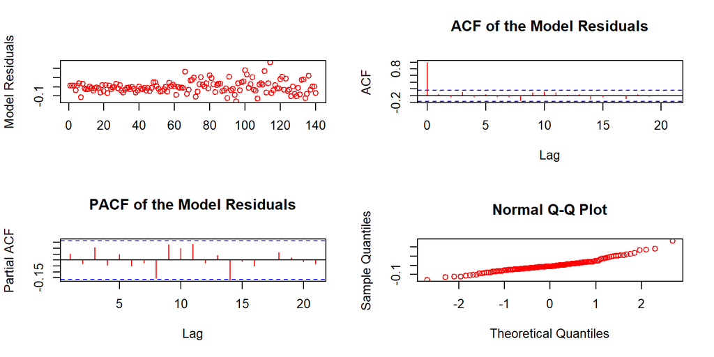

```r
# residuals analysis
resids = mod$resid[(mod$order+1): length(mod$resid)]

par(mfrow=c(2,2))
plot(resids,xlab="",ylab="Model Residuals", col="red")
acf(resids,main='ACF of the Model Residuals', col="red")
pacf(resids,main='PACF of the Model Residuals', col="red")
qqnorm(resids, col="red")
```

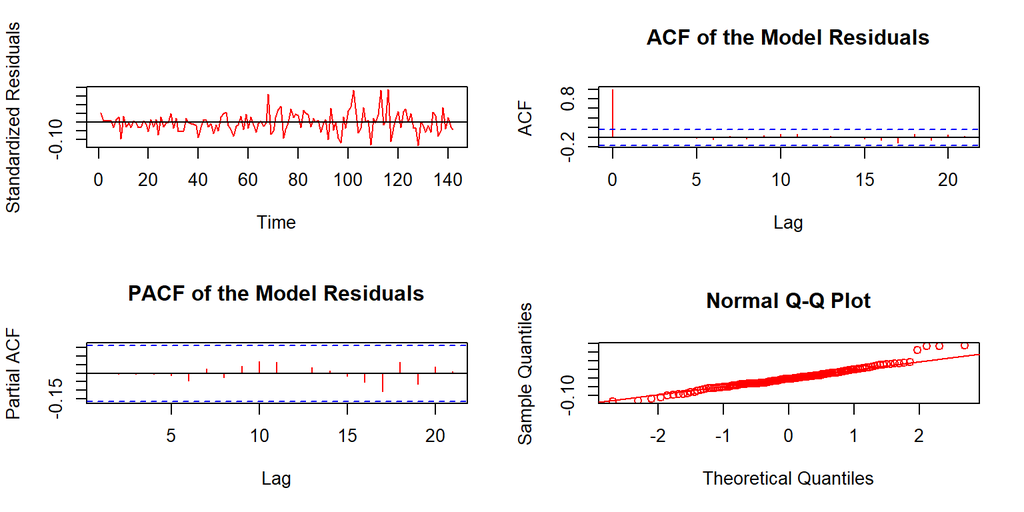

```r
###### Fit an ARMA(p,q) for some values of p and q #####
modarma = arima(TimeSeriesData, order = c(8,0,8),method = "ML")

par (mfrow=c(2,2))
plot(resid(modarma), ylab='Standardized Residuals', col="red")
abline(h=0)
acf(as.vector(resid(modarma)),main= 'ACF of the Model Residuals', col="red")
pacf(as.vector(resid(modarma)),main='PACF of the Model Residuals', col="red")
qqnorm(resid(modarma), col="red")
qqline(resid(modarma), col="red")
```

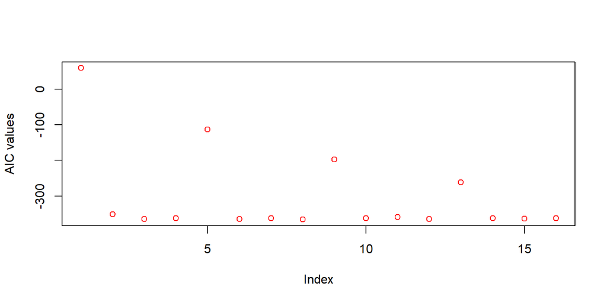

```r
## Order selection -- AIC
n = length(TimeSeriesData)
norder = 4
p = c(1:norder)-1; q = c(1:norder)-1
aic = matrix(0,norder,norder)
for(i in 1:norder){
   for(j in 1:norder){
    modij = arima(TimeSeriesData,order = c(p[i],0,q[j]), method='ML')
    aic[i,j] = modij$aic-2*(p[i]+q[j]+1)+2*(p[i]+q[j]+1)*n/(n-p[i]-q[j]-2)
   }
 }



par(mfrow=c(1,1))
#which order to select?
aicv = as.vector(aic)
plot(aicv,ylab="AIC values", col="red")
```

```r
indexp = rep(c(1:norder),norder)
indexq = rep(c(1:norder),each=norder)
indexaic = which(aicv == min(aicv))
porder = indexp[indexaic]-1
qorder = indexq[indexaic]-1

porder
```

```
## [1] 3
```

```r
qorder
```

```
## [1] 1
```

```r
min(aicv)
```

```
## [1] -365.8766
```

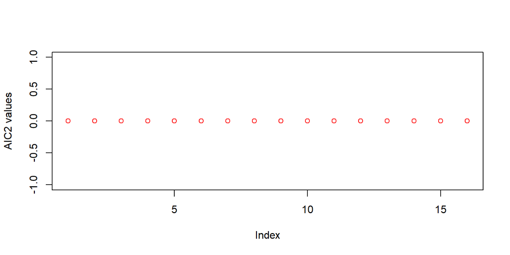

```r
p = c(1:norder)-1; q = c(1:norder)-1
aic2 = matrix(0,norder,norder)
for(i in 1:norder){
   for(j in 1:norder){
    modij = arima(TimeSeriesData,order = c(p[i],1,q[j]), method='ML')
    aic[i,j] = modij$aic-2*(p[i]+q[j]+1)+2*(p[i]+q[j]+1)*n/(n-p[i]-q[j]-2)
   }
 }
aicv2 = as.vector(aic2)
plot(aicv2,ylab="AIC2 values", col="red")
```

```r
indexp2 = rep(c(1:norder),norder)
indexq2 = rep(c(1:norder),each=norder)
indexaic2 = which(aicv2 == min(aicv2))
porder2 = indexp2[indexaic2]-1
qorder2 = indexq2[indexaic2]-1

porder2
```

```
##  [1] 0 1 2 3 0 1 2 3 0 1 2 3 0 1 2 3
```

```r
qorder2
```

```
##  [1] 0 0 0 0 1 1 1 1 2 2 2 2 3 3 3 3
```

```r
min(aicv2)
```

```
## [1] 0
```

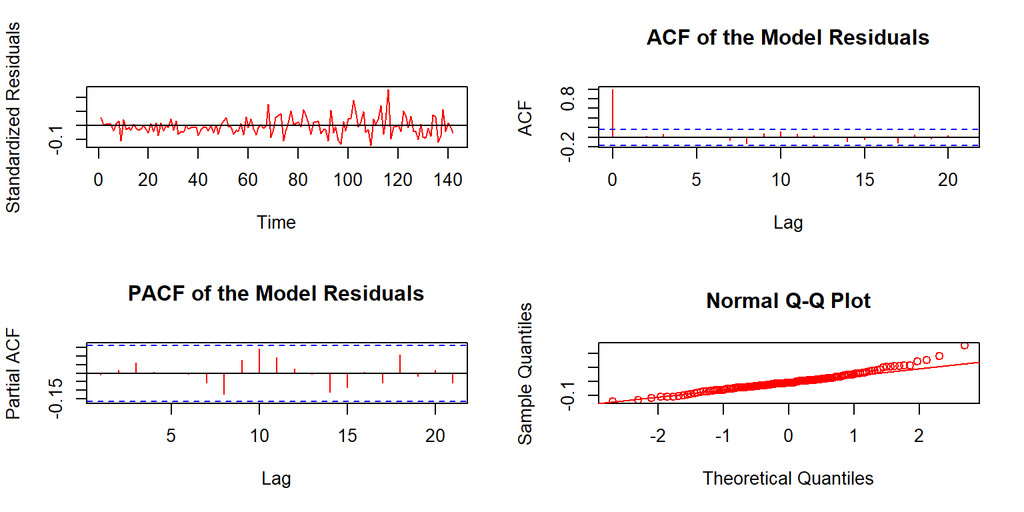

```r
#Create Final Model
final_model = arima(TimeSeriesData,order = c(porder,0,qorder), method='ML')

par (mfrow=c(2,2))
plot(resid(final_model), ylab='Standardized Residuals', col="red")
abline(h=0)
acf(as.vector(resid(final_model)),main= 'ACF of the Model Residuals', col="red")
pacf(as.vector(resid(final_model)),main='PACF of the Model Residuals', col="red")
qqnorm(resid(final_model), col="red")
qqline(resid(final_model), col="red")
```